# Pre-Regression Steps - Scatter Plot: Scatter Plot Matrices

```python
import pandas as pd
import numpy as np
```

```python
ip=pd.read_csv(r'wages_formatted_fullvalues.csv',index_col=False)
```

```python
print ip.shape
print ip.columns
```

```
(534, 11)
Index([u'EDUCATION: Number of years of education',
       u'SOUTH: 1=Person lives in South, 0=Person lives elsewhere',
       u'SEX: 1=Female, 0=Male',
       u'EXPERIENCE: Number of years of work experience',
       u'UNION: 1=Union member, 0=Not union member',
       u'WAGE: Wage (dollars per hour)', u'AGE: years',
       u'RACE: 1=Other, 2=Hispanic, 3=White',
       u'OCCUPATION: 1=Management, 2=Sales, 3=Clerical, 4=Service, 5=Professional, 6=Other',
       u'SECTOR: 0=Other, 1=Manufacturing, 2=Construction',
       u'MARR: 0=Unmarried,  1=Married'],
      dtype='object')
```

```python
#ip['log10(WAGE)'] = np.log10(ip['WAGE: Wage (dollars per hour)'])
# Log-transform the wages, because they typically are increased with multiplicative factors
```

```python
import matplotlib.pyplot as plt
import seaborn as sns
%matplotlib inline
```

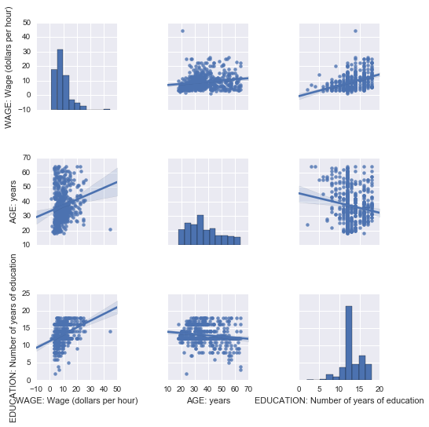

```python
#sns.pairplot(ip, vars=['log10(WAGE)', 'AGE: years', 'EDUCATION: Number of years of education'],kind='reg')
sns.pairplot(ip, vars=['WAGE: Wage (dollars per hour)', 'AGE: years', 'EDUCATION: Number of years of education'],kind='reg')
#We can easily have an intuition on the interactions between continuous variables
#using seaborn.pairplot() to display a scatter matrix
```

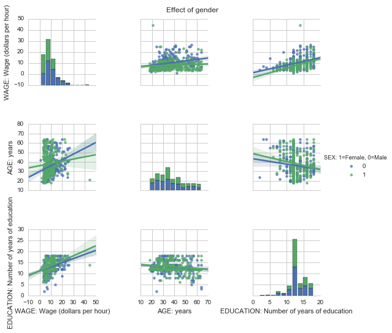

```python
#sns.pairplot(ip, vars=['log10(WAGE)', 'AGE: years', 'EDUCATION: Number of years of education'],kind='reg',hue='SEX: 1=Female, 0=Male')
plt.figure(figsize=(25,25))
sns.set_context("notebook", font_scale=1)
sns.set_style('whitegrid')
sns.pairplot(ip, vars=['WAGE: Wage (dollars per hour)', 'AGE: years', 'EDUCATION: Number of years of education'],kind='reg',hue='SEX: 1=Female, 0=Male')
plt.suptitle('Effect of gender')
#Categorical variables can be plotted as the hue
```

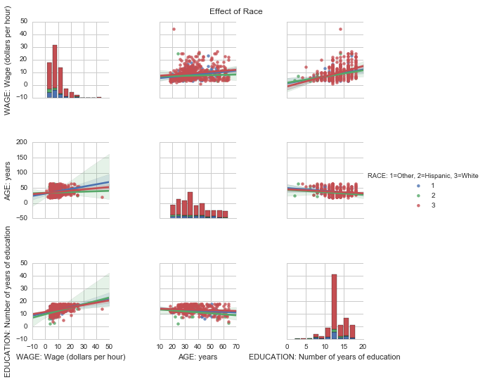

```python
#sns.pairplot(ip, vars=['log10(WAGE)', 'AGE: years', 'EDUCATION: Number of years of education'],kind='reg',hue='SEX: 1=Female, 0=Male')
plt.figure(figsize=(25,25))
sns.set_context("notebook", font_scale=1)
sns.set_style('whitegrid')
sns.pairplot(ip, vars=['WAGE: Wage (dollars per hour)', 'AGE: years', 'EDUCATION: Number of years of education'],kind='reg',hue='RACE: 1=Other, 2=Hispanic, 3=White')
plt.suptitle('Effect of Race')
#Categorical variables can be plotted as the hue
```

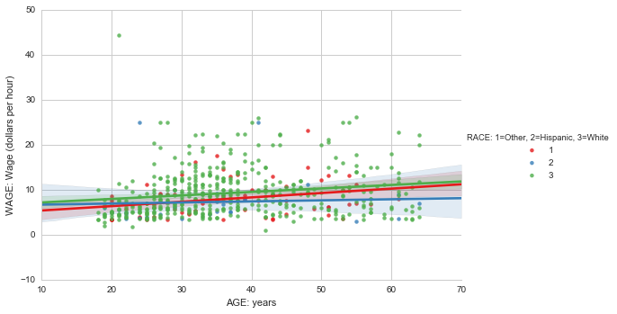

```python
sns.lmplot(x = 'AGE: years', y = 'WAGE: Wage (dollars per hour)', data = ip, hue = "RACE: 1=Other, 2=Hispanic, 3=White", palette="Set1", fit_reg = True,size=5,aspect=1.5)
#linear model plot
#source: http://seaborn.pydata.org/generated/seaborn.lmplot.html
```

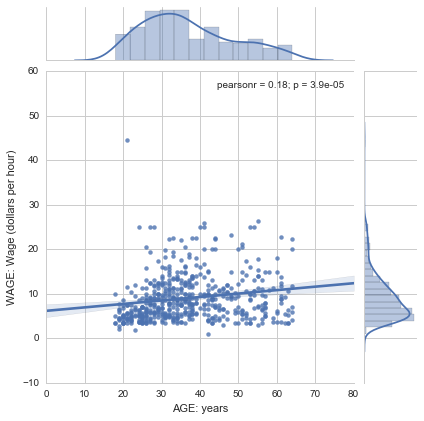

```python
sns.jointplot(y='WAGE: Wage (dollars per hour)', x='AGE: years', data=ip,kind='reg')
#Joint distribution plots combine information from scatter plots and histograms
#to give you detailed information for bi-variate distributions
```

# Pre-regression Steps - Standardization and Normalization

The process for getting data ready for a machine learning algorithm can be summarized in two main steps:

```
1. Data Pre-Processing - involving formatting (what if numerical variable is in string/object format), cleaning (missing value, outlier treatment), etc.,
2. Data Transformation/ Data Scaling
```

Many machine learning methods expect or are more effective if the data attributes have the same scale. Data rescaling is an important part of data preparation before applying machine learning algorithms

Two popular data scaling methods are

1. normalization - refers to rescaling numeric attributes into the range 0 and 1
2. standardization - refers to shifting the distribution of each attribute to have a mean of zero and a standard deviation of one (unit variance)

```python
from sklearn import preprocessing
```

```python
#creation of data frame with only the dependent continuous variables
new_dependent_data=ip.drop(['WAGE: Wage (dollars per hour)'],axis=1)
```

```python
new_dependent_data.columns
```

[output not shown]

```python
#min-max scaling method of normalization
new_dependent_data_normalized=(new_dependent_data-new_dependent_data.min())/(new_dependent_data.max()-new_dependent_data.min())
```

```python
new_dependent_data_normalized.head(5)
```

[output not shown]

```python
new_dependent_data_normalized.describe()
```

[output not shown]

###### In the above min-max scaling/ "Data Normalization", all values are in the range (0,1) with min = 0 and max = 1

```python
#z-score normalizing or Data Standardization
```

```python
new_dependent_data_normalized_2=(new_dependent_data-new_dependent_data.mean())/(new_dependent_data.std())
```

```python
new_dependent_data_normalized_2.head(5)
```

[output not shown]

```python
new_dependent_data_normalized_2.describe()
```

[output not shown]

###### In the above zscore scaling/ "Data standardization",

- the mean of each column is zero (or very close to zero)
- the standard deviation of each column is one (or very close to one)

Important Points

- **Should/Can we normalize Categorical variables?**

  ```
    For regression and classification it would NOT matter if we perform scaling/normalization of categorical variables
  ```

- **Which normalization to use?**

  ```
    It is hard to know whether rescaling your data will improve the performance of your algorithms before you apply them.
    It often can, but not always
  ```

- **There are other simple transformations also**

  ```
    df_normalized=df/df.max()
    or any custom transformation like log or exponential
  ```